# Graphs

Pavel Kucherbaev

09 November 2017

# Introduction to Graphs

# Part 1: Outline

- What is a graph
- Directions and cycles
- Graph representation

# Not about

### Charts and Grafs

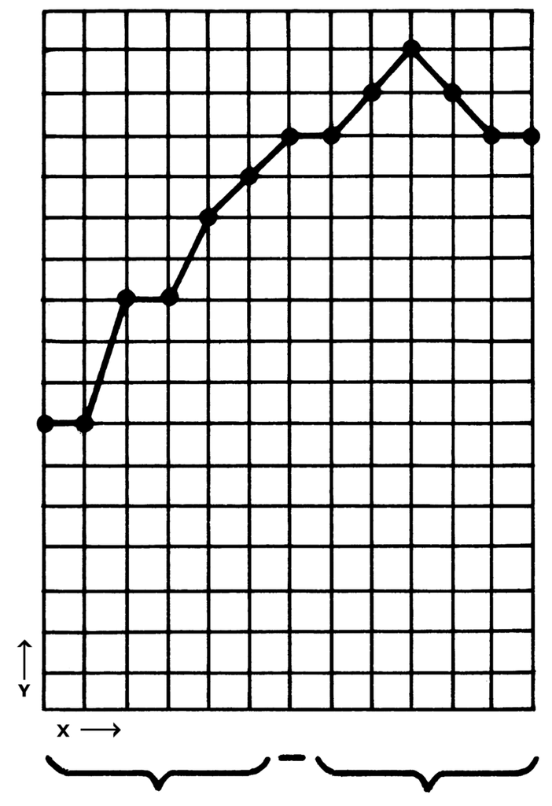

[figure not shown]

# Nodes represent objects

(e.g. people, cities, countries, computers).

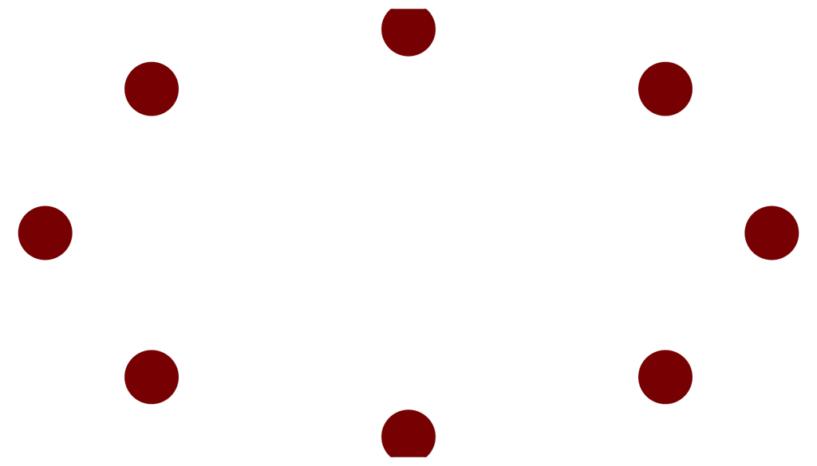

Nodes can be called vertices as well.

# Edges represent relationships

(e.g. friendship, connectedness)

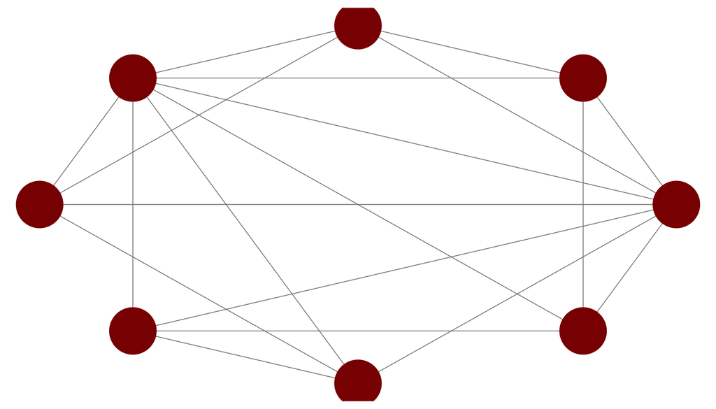

Graphs can be called networks as well.

# Direction of relationships

(e.g. A follows B, A is a student of B)

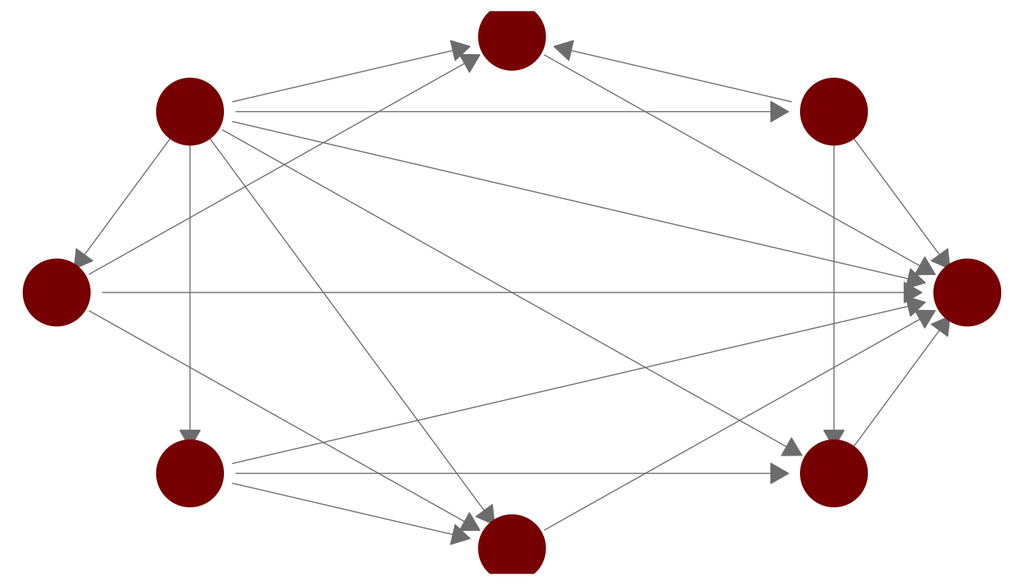

Does it remind you something?

# Blood donation

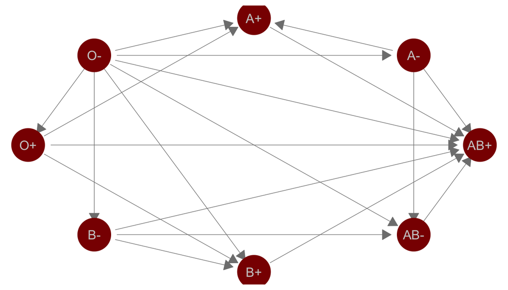

# Position of nodes

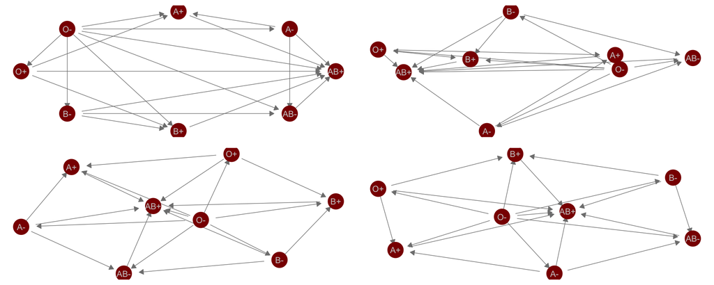

Does not change semantics of the graph

# Weights

(e.g. cost of travel, distance, energy to transition)

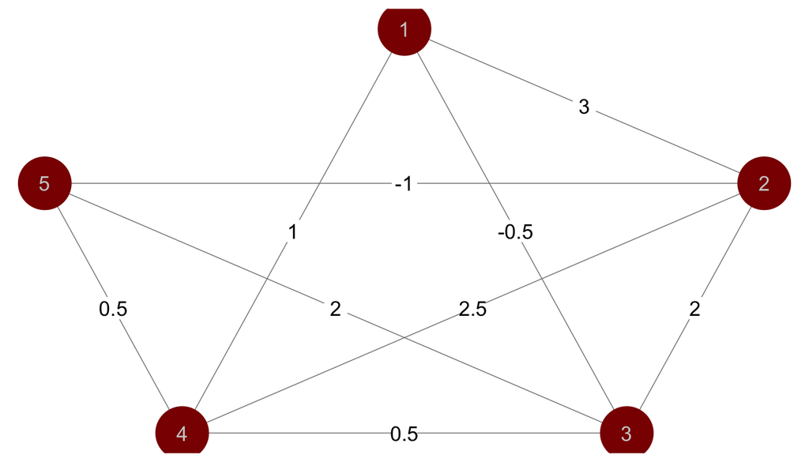

In a directional graph cost in one direction could be different than back (e.g. going up hill and downhill).

# Degree

Number of edges incident on a node.

degree(“1”) = 3; degree(“3”) = 4

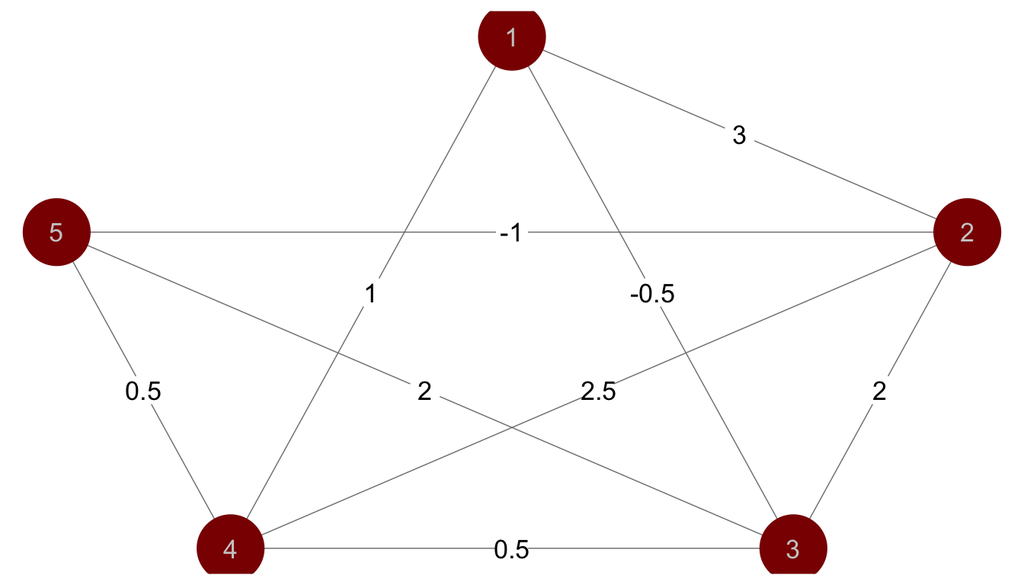

# Graph representation

We can define a graph using:

- Edge list
- Adjacency list
- Adjacency matrix

# Edge list

[Edge1, Edge2, Edge3, Edge4]

Edge1 = [Node1, Node2]

```python
edge_list = [[0,1],[1,2],[1,3],[2,3]]
```

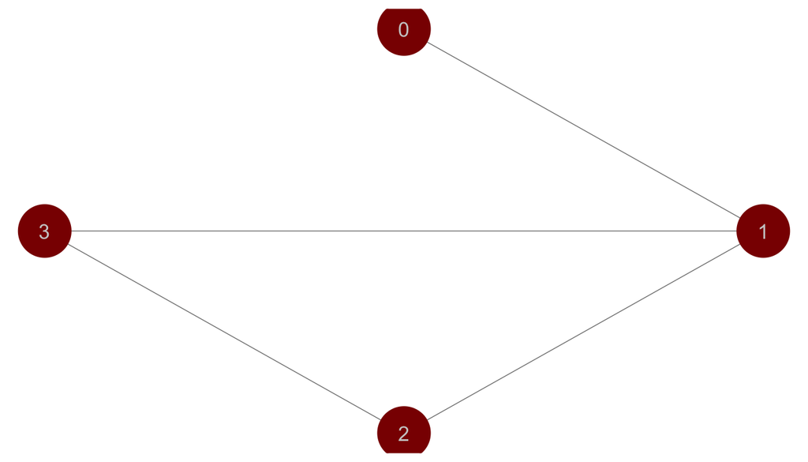

# Adjacency list

[Node1Conns, Node2Conns, Node3Conns, Node4Conns]

Node1Conns = [Node2, Node3]

```python
adj_list = [[1],[0,2,3],[1,3],[1,2]]
```

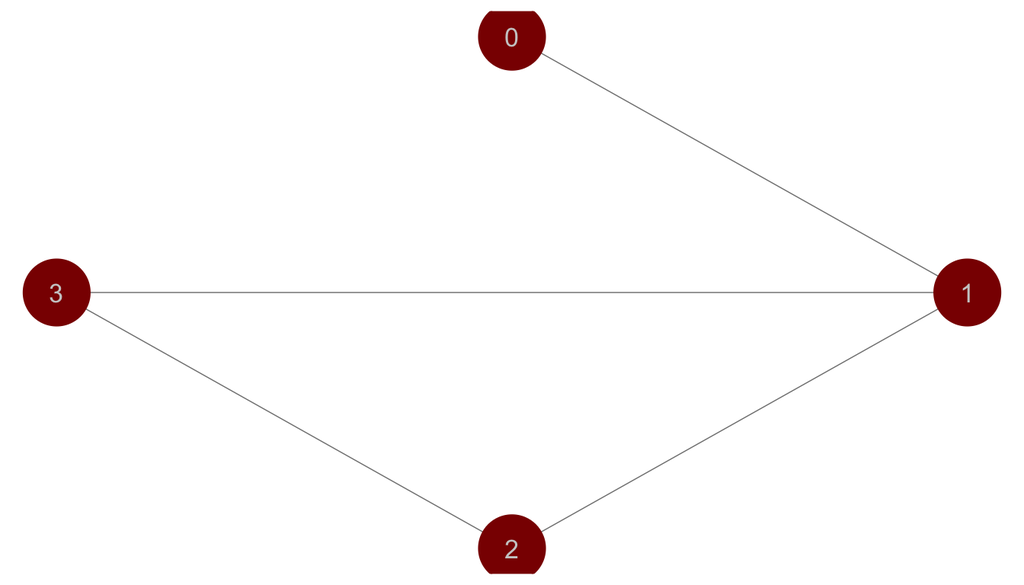

# Adjacency list

More efficient storage options for sparce graphs

```python
adj_list = [[1],[0,2,3],[1,3],[1,2],[],[],[],[],[],[],[],[],[],[]]


adj_dict = {
  "v0": ["v1"],
  "v1": ["v0","v2","v3"],
  "v2": ["v1","v3"],
  "v3": ["v1","v2"]
}


adj_dict_weights = {
  "v0": {"v1":1},
  "v1": {"v0":1,"v2":1,"v3":1},
  "v2": {"v1":1,"v3":1},
  "v3": {"v1":1,"v2":1}
}
```

# Adjacency matrix

Column names = Nodes, Row names = Nodes, Cells = Edges

```python
adj_matrix = [
[0, 1, 0, 0],
[1, 0, 1, 1],
[0, 1, 0, 1],
[0, 1, 1, 0],
]
```

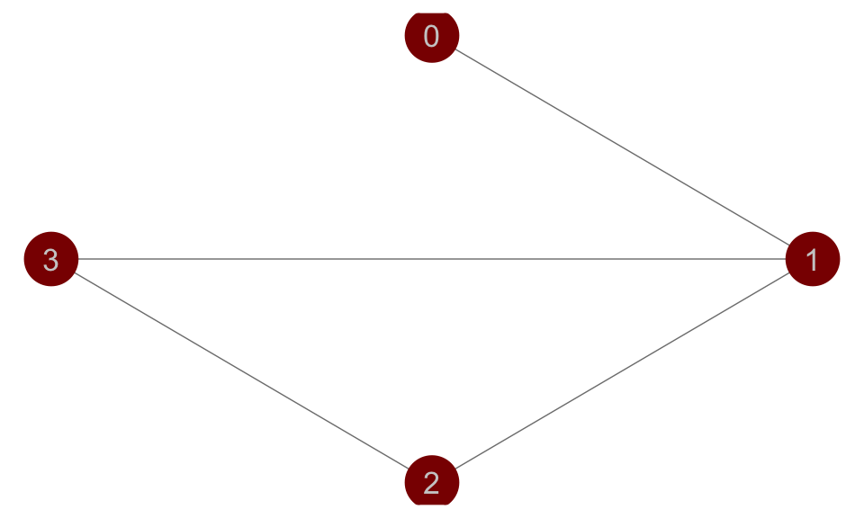

# Adjacency matrix

Non directional graph.

Cells are symmetrical across the main diagonal.

```python
adj_matrix = [
[0, 1, 0, 0],
[1, 0, 1, 1],
[0, 1, 0, 1],
[0, 1, 1, 0],
]
```

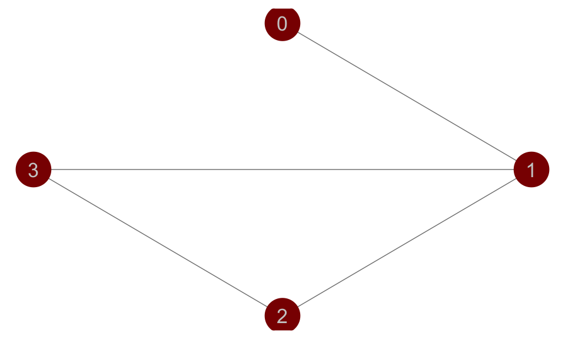

# Adjacency matrix

Directional graph.

```python
adj_matrix = [
[0, 1, 0, 0],
[1, 0, 1, 1],
[1, 0, 0, 1],
[0, 0, 0, 0],
]
```

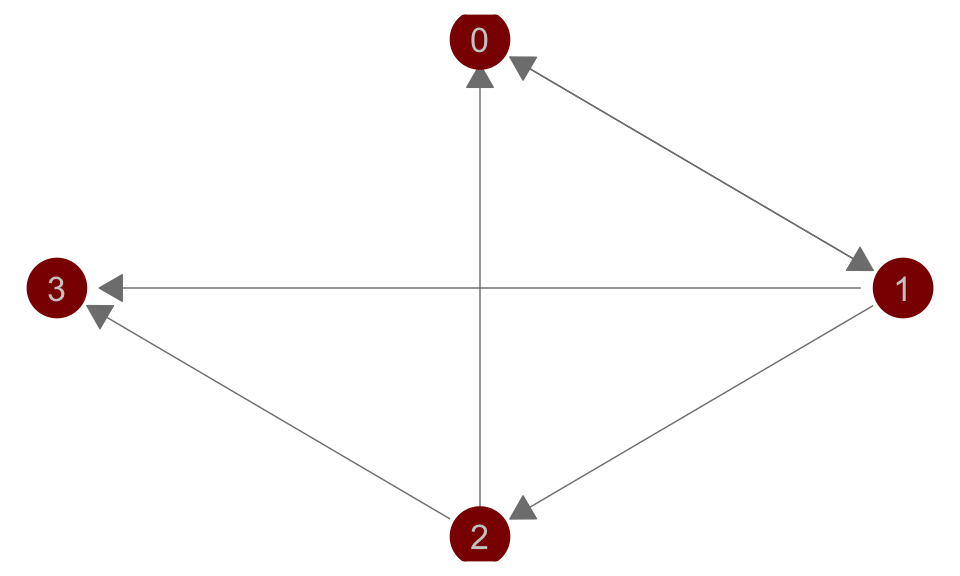

# Adjacency matrix

Directional graph with weights.

```python
adj_matrix = [
[0, 1, 0, 0],
[1, 0, 3, 1],
[2, 0, 0, 1],
[0, 0, 0, 0],
]
```

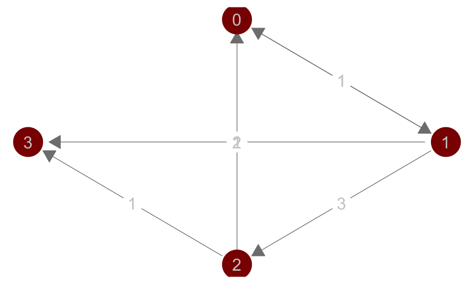

# Part 2: Outline

- Euler path, Hamiltonian path
- Types of graphs
- Centrality (e.g. betweenness, closeness, eigenvector, node)

# Traversal

# Cycle

Trees can not have cycles. Graphs can have cycles.

# Hamiltonian path

Hamiltonian cycle is Hamiltonian path which is a cycle.

# Eulerian path

# Types of graphs

- Empty
- Star
- Tree
- Ring
- Full
- Bipartite

# Empty Graph

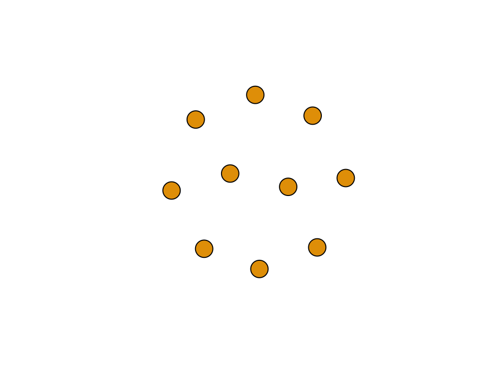

# Star Graph

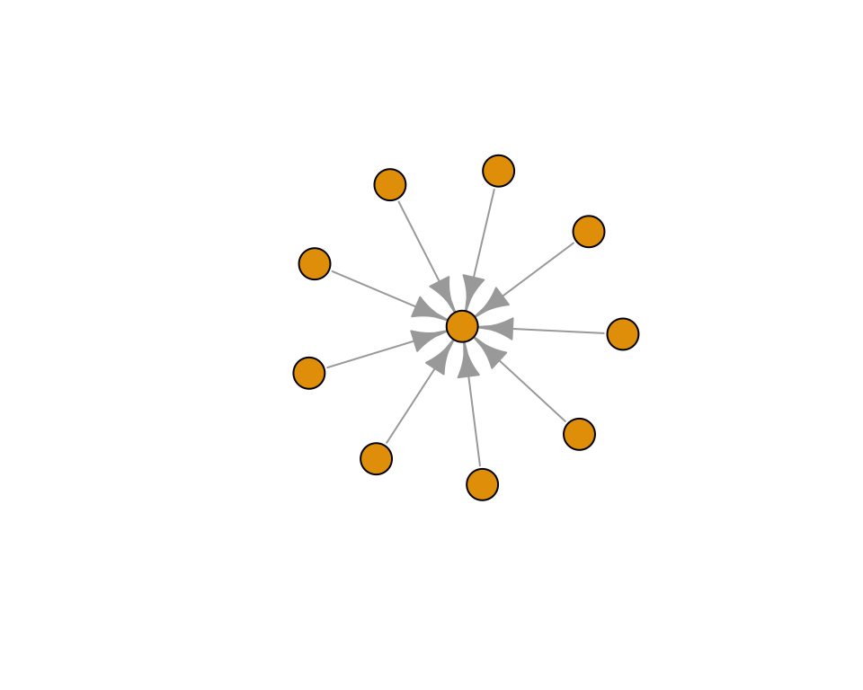

# Tree Graph

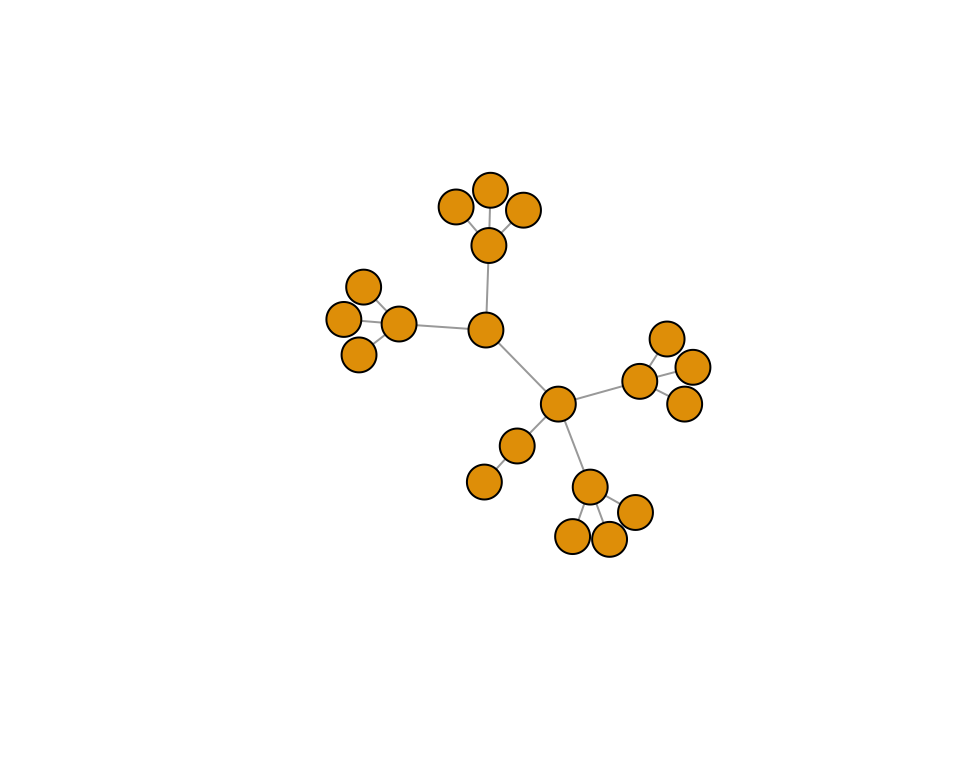

# Ring Graph

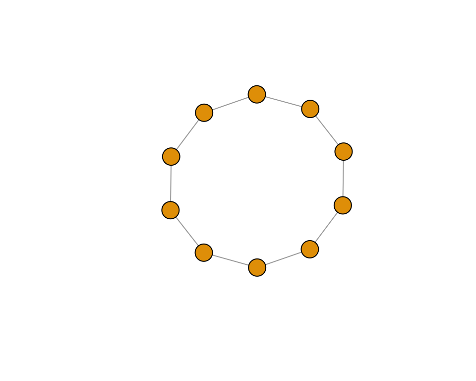

# Full Graph

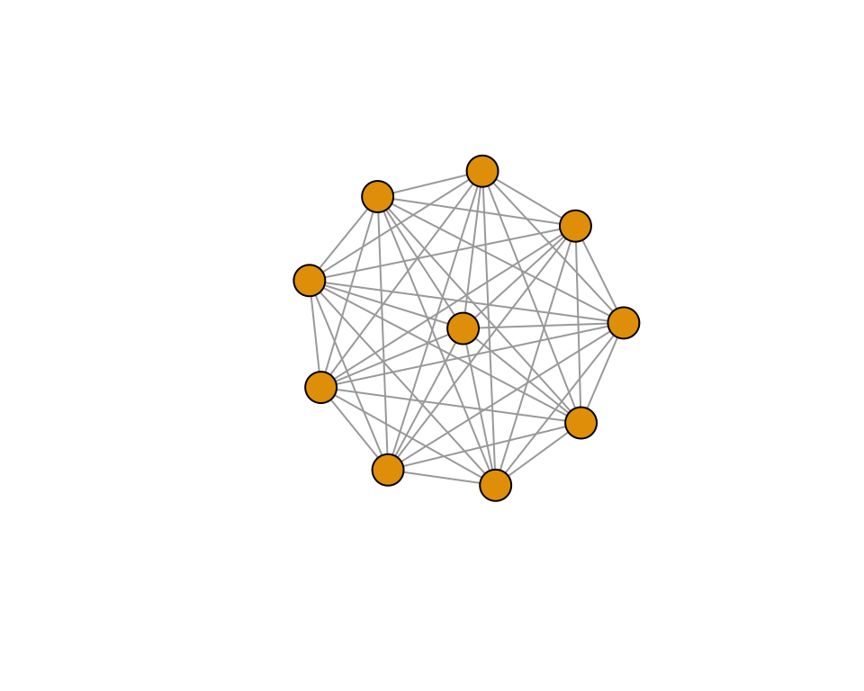

# Bipartite Graph

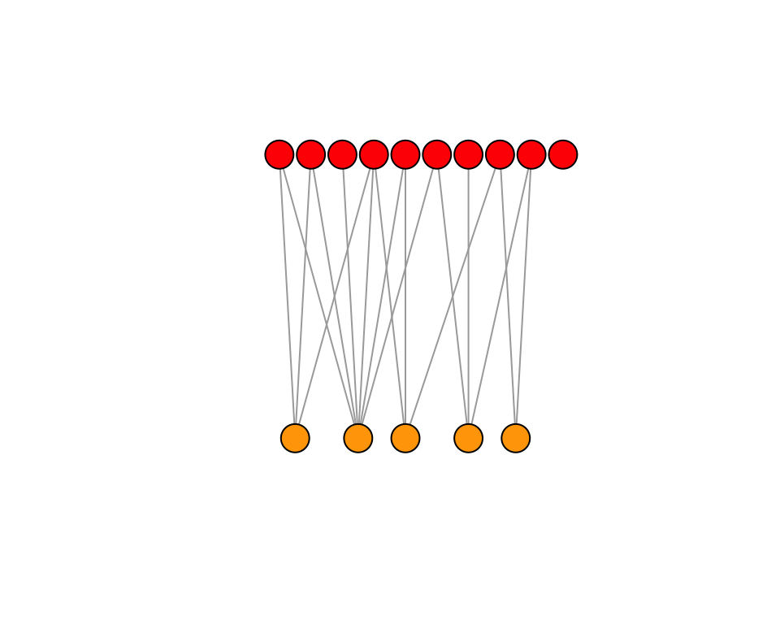

# Graph in Python

# Search Algorithms for Graphs

# Part 1

- Bredth-first search
- Depth-first search

# Part 2

- Shortest path. Dijkstra algorithm.
- All-pairs shortest path.
- Recap of the material

# References

# Sources used to prepare this lecture

- https://classroom.udacity.com/courses/cs215/
- https://classroom.udacity.com/courses/ud513/
- the book Introduction to algorithms
- https://briatte.github.io/ggnet/
- http://kateto.net/network-visualization
- https://www.udacity.com/wiki/creating-network-graphs-with-python
- http://www.kateto.net/wp-content/uploads/2016/01/NetSciX_2016_Workshop.pdf
- https://rstudio-pubs-static.s3.amazonaws.com/74248_3bd99f966ed94a91b36d39d8f21e3dc3.html